# Distances between ranked tree shapes example for n=5

Jaehee Kim

2019-12-30

This vignette demonstrates generation of F-matrices and a distance matrix between ranked tree shapes with $n=5$. a simple example

We first load all five ranked tree shapes for $n=5$.

```r
library(phylodyn)
data(tr_list)
```

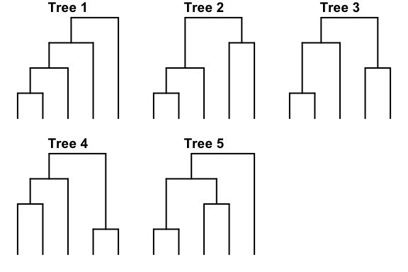

We now generate F-matrix for each ranked tree shape.

```r
Fmat_list <- list()
for (i in 1:length(tr_list)) {
    Fmat_list[[i]] <- gen_Fmat(tr_list[[i]])
}
print(Fmat_list)
```

```
## [[1]]
##      [,1] [,2] [,3] [,4]
## [1,]    2    0    0    0
## [2,]    1    3    0    0
## [3,]    1    2    4    0
## [4,]    1    2    3    5
##
## [[2]]
##      [,1] [,2] [,3] [,4]
## [1,]    2    0    0    0
## [2,]    1    3    0    0
## [3,]    0    2    4    0
## [4,]    0    2    3    5
##
## [[3]]
##      [,1] [,2] [,3] [,4]
## [1,]    2    0    0    0
## [2,]    1    3    0    0
## [3,]    0    2    4    0
## [4,]    0    1    3    5
##
## [[4]]
##      [,1] [,2] [,3] [,4]
## [1,]    2    0    0    0
## [2,]    1    3    0    0
## [3,]    1    2    4    0
## [4,]    0    1    3    5
##
## [[5]]
##      [,1] [,2] [,3] [,4]
## [1,]    2    0    0    0
## [2,]    1    3    0    0
## [3,]    1    2    4    0
## [4,]    1    1    3    5
```

We next compute pairwise distances between above five ranked tree shapes for $n=5$. In this example, we use $L_1$ distance and considers ranked tree shapes only (i.e., unweighted).

```r
dmat <- matrix(0, nrow=length(tr_list), ncol=length(tr_list))
for (i in 1:length(tr_list)) {
    for (j in 1:i) {
        dmat[i,j] <- dist_pairwise(tr_list[[i]], tr_list[[j]], dist.method="l1", weighted=FALSE)
    }
}
tmp <- dmat[lower.tri(dmat)]
dmat <- t(dmat)
dmat[lower.tri(dmat)] <- tmp
print(dmat)
```

```
##      [,1] [,2] [,3] [,4] [,5]
## [1,]    0    2    3    2    1
## [2,]    2    0    1    2    3
## [3,]    3    1    0    1    2
## [4,]    2    2    1    0    1
## [5,]    1    3    2    1    0
```

We can visualize the MDS of those 5 trees:

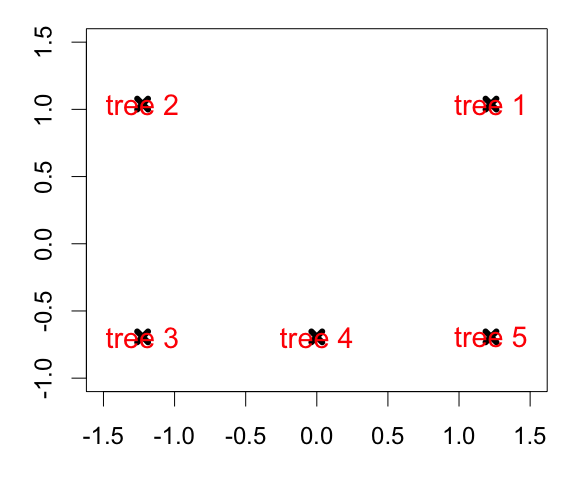

```r
mds <- cmdscale(dmat, eig=T, k=2)
par(mar=c(3,3,1,1), cex=1.5)
plot(mds$points, xlab='', ylab='', pch=4, lwd=6,
     xlim=c(-1.5, 1.5), ylim=c(-1, 1.5))
text(mds$points[,1:2], labels=paste('tree', 1:5), col='red', cex=1.2)
```

We also compute the distances with adaptations of other tree distances to ranked tree shapes. To adapt other metrics, we assign unique labels to leaves:

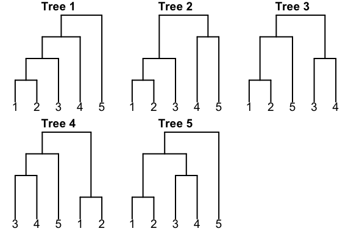

```r
n_tr <- length(tr_list)

# ==== d1 ====
d1.dmat <- matrix(0, nrow=n_tr, ncol=n_tr)
for (i in 1:n_tr) {
    for (j in 1:n_tr) {
        d1.dmat[i,j] <- dist_pairwise(tr_list[[i]], tr_list[[j]],
                                      dist.method="l1", weighted=FALSE)
    }
}

# ==== d2 ====
d2.dmat <- matrix(0, nrow=n_tr, ncol=n_tr)
for (i in 1:n_tr) {
    for (j in 1:n_tr) {
        d2.dmat[i,j] <- dist_pairwise(tr_list[[i]], tr_list[[j]],
                                      dist.method="l2", weighted=FALSE)
    }
}

# ==== d_{CP-RTS} ====
cp.dmat <- matrix(0, nrow=n_tr, ncol=n_tr)
tmp <- treetop::vecMultiDistUnlab(tr_list)
cp.dmat[lower.tri(cp.dmat)] <- tmp
cp.dmat <- t(cp.dmat)
cp.dmat[lower.tri(cp.dmat)] <- tmp

# ==== d_{RF-RTS} ====
rf.dmat <- matrix(0, nrow=n_tr, ncol=n_tr)
tmp <- phangorn::RF.dist(tr_list_lab, normalize=FALSE,
                         check.labels=TRUE,
                         rooted=TRUE)
rf.dmat[lower.tri(rf.dmat)] <- tmp
rf.dmat <- t(rf.dmat)
rf.dmat[lower.tri(rf.dmat)] <- tmp

# ==== d_{KC-RTS} ====
kc1.dmat <- matrix(0, nrow=n_tr, ncol=n_tr)
tmp <- treespace::multiDist(tr_list_lab, lambda=0)
kc1.dmat[lower.tri(kc1.dmat)] <- tmp
kc1.dmat <- t(kc1.dmat)
kc1.dmat[lower.tri(kc1.dmat)] <- tmp

# ==== d_{KC-RTS*} ====
kc2.dmat <- matrix(0, nrow=n_tr, ncol=n_tr)
tmp <- treespace::multiDist(tr_list_lab, lambda=0.5)
kc2.dmat[lower.tri(kc2.dmat)] <- tmp
kc2.dmat <- t(kc2.dmat)
kc2.dmat[lower.tri(kc2.dmat)] <- tmp

# ==== d_{BHV-RTS} ====
bhv.dmat <- matrix(0, nrow=n_tr, ncol=n_tr)
tmp <- distory::dist.multiPhylo(tr_list_lab)
bhv.dmat[lower.tri(bhv.dmat)] <- tmp
bhv.dmat <- t(bhv.dmat)
bhv.dmat[lower.tri(bhv.dmat)] <- tmp

# ==== d_{BHV-RTS*} ====
bhv2.dmat <- matrix(0, nrow=n_tr, ncol=n_tr)
lab.perm <- combinat::permn(1:n_tr)
tmp.vec <- rep(NA, 10)
counter.vec <- 0
for (i in 1:n_tr) {
    for (j in 1:n_tr) {
        print(c(i,j))
        if (i < j) {
            tr.1 <- tr_list_lab[[i]]
            tr.2 <- tr_list_lab[[j]]
            tr.edge.1 <- tr.1$edge
            tr.edge.2 <- tr.2$edge
            tip.ind.1 <- which(tr.1$edge[,2] < 6)
            tip.ind.2 <- which(tr.2$edge[,2] < 6)
            tmp.list.1 <- list()
            tmp.list.2 <- list()
            for (k in 1:length(lab.perm)) {
                tr.edge.1[tip.ind.1, 2] <- lab.perm[[k]]
                tr.edge.2[tip.ind.2, 2] <- lab.perm[[k]]
                tr.1$edge <- tr.edge.1
                tr.2$edge <- tr.edge.2
                tmp.list.1[[k]] <- tr.1
                tmp.list.2[[k]] <- tr.2
            }
            tmp.dist <- rep(NA, length(lab.perm)*length(lab.perm))
            counter <- 0
            for (ind.1 in 1:length(lab.perm)) {
                for (ind.2 in 1:length(lab.perm)) {
                    counter <- counter + 1
                    tmp.dist[counter] <- c(distory::dist.multiPhylo(list(tmp.list.1[[ind.1]], tmp.list.2[[ind.2]])))
                }
            }
            counter.vec <- counter.vec + 1
            tmp.vec[counter.vec] <- min(tmp.dist)
        }
    }
}
bhv2.dmat[lower.tri(bhv2.dmat)] <- tmp.vec
bhv2.dmat <- t(bhv2.dmat)
bhv2.dmat[lower.tri(bhv2.dmat)] <- tmp.vec
```

Print distance matrices of all distance functions computed.

```
## $d_1
##      [,1] [,2] [,3] [,4] [,5]
## [1,]    0    2    3    2    1
## [2,]    2    0    1    2    3
## [3,]    3    1    0    1    2
## [4,]    2    2    1    0    1
## [5,]    1    3    2    1    0
##
## $d_2
##      [,1] [,2] [,3] [,4] [,5]
## [1,] 0.00 1.41 1.73 1.41 1.00
## [2,] 1.41 0.00 1.00 1.41 1.73
## [3,] 1.73 1.00 0.00 1.00 1.41
## [4,] 1.41 1.41 1.00 0.00 1.00
## [5,] 1.00 1.73 1.41 1.00 0.00
##
## $`d_{CP-RTS}`
##      [,1] [,2] [,3] [,4] [,5]
## [1,] 0.00    2    2    2 2.45
## [2,] 2.00    0    0    0 2.00
## [3,] 2.00    0    0    0 2.00
## [4,] 2.00    0    0    0 2.00
## [5,] 2.45    2    2    2 0.00
##
## $`d_{RF-RTS}`
##      [,1] [,2] [,3] [,4] [,5]
## [1,]    0    2    4    4    2
## [2,]    2    0    4    4    4
## [3,]    4    4    0    2    2
## [4,]    4    4    2    0    2
## [5,]    2    4    2    2    0
##
## $`d_{KC-RTS}`
##      [,1] [,2] [,3] [,4] [,5]
## [1,] 0.00 2.65 3.61 4.12 2.00
## [2,] 2.65 0.00 2.45 2.83 2.65
## [3,] 3.61 2.45 0.00 2.45 2.65
## [4,] 4.12 2.83 2.45 0.00 2.65
## [5,] 2.00 2.65 2.65 2.65 0.00
##
```

[output cut: 8 more lines]

```
## $`d_{BHV-RTS}`
##      [,1] [,2] [,3] [,4] [,5]
## [1,] 0.00 2.45 3.74 3.46 2.45
## [2,] 2.45 0.00 3.46 3.74 3.74
## [3,] 3.74 3.46 0.00 2.45 2.45
## [4,] 3.46 3.74 2.45 0.00 2.45
## [5,] 2.45 3.74 2.45 2.45 0.00
##
## $`d_{BHV-RTS*}`
##      [,1] [,2] [,3] [,4] [,5]
## [1,] 0.00 2.45 3.74 3.46 2.45
## [2,] 2.45 0.00 2.45 3.74 3.74
## [3,] 3.74 2.45 0.00 2.45 2.45
## [4,] 3.46 3.74 2.45 0.00 2.45
## [5,] 2.45 3.74 2.45 2.45 0.00
```

We now simulate 10 trees with n=50 tips from 5 different Beta-splitting distributions. The random trees are generated using the code by Maliet 2018. We compute the pairwaise L1 distance matrix of 50 by 50 and plot the MDS of the distance matrix:

```r
rand.seed <- 56
treetypes <- c("balanced", "yule", "ab", "pda", "unbalanced")
n.sim <- 10 # number of simulations
n.tip <- 50 # number of tips
n.model <- length(treetypes)
set.seed(rand.seed)
iso.Fmat.list <- list()
iso.tr.list <- list()
for (i in 1:length(treetypes)) {
    t.mode <- treetypes[i]
    print(t.mode)
    alpha <- 1
    eta <- 1
    epsilon <- 0.001 # the same value used in Maliet, Gascuel, and Lambert (2018)
    if (t.mode == 'balanced') {
        beta <- 100
    } else if (t.mode == 'yule') {
        beta <- 0
    } else if (t.mode == 'ab') {
        beta <- -1
    } else if (t.mode == 'pda') {
        beta <- -1.5
    } else if (t.mode == 'unbalanced') {
        beta <- -1.9
    }

    iso.tr.list[[i]] <- list()
    iso.Fmat.list[[i]] <-list()
    for (j  in 1:n.sim) {
        tmp.tr <- apTreeshape::simulate_tree(epsilon=epsilon, alpha=alpha, beta=beta, N=n.tip)
        iso.tr.list[[i]][[j]] <- tmp.tr
        iso.Fmat.list[[i]][[j]] <- gen_Fmat(tmp.tr)
    }
}

names(iso.tr.list) <- treetypes
names(iso.Fmat.list) <- treetypes
```

Compute L1 unweighted distance matrix.

```r
iso.all.Fmat <- unlist(iso.Fmat.list, recursive=FALSE)
iso.all.tr <- unlist(iso.tr.list, recursive=FALSE)
dmat.L1 <- matrix(0, nrow=length(iso.all.tr), ncol=length(iso.all.tr))

for (i in 2:length(iso.all.tr)) {
    print(paste('computing distances from tree', i))
    for (j in 1:(i-1)) {
        dmat.L1[i,j] <- dist_pairwise(iso.all.tr[[i]], iso.all.tr[[j]],
                                      dist.method="l1", weighted=FALSE)
    }
}

tmp <- c(dmat.L1[lower.tri(dmat.L1)])
dmat.L1 <- t(dmat.L1)
dmat.L1[lower.tri(dmat.L1)] <- tmp
```

Find sample Frechet mean tree and medoid tree from the distance matrix.

```r
## Find medoid tree index
find.medoid <- function(dmat) {
    total.dist <- apply(dmat, 1, sum)
    return(which(total.dist == min(total.dist)))
}

# Find sample frechet mean tree index
find.frechet.mean <- function(dmat) {
    total.dist <- apply(dmat^2, 1, sum)
    return(which(total.dist == min(total.dist)))
}

f.pts <- list()
for (i in 1:n.model) {
    tr.ind <- ((i-1)*n.sim + 1):(i*n.sim)
    f.pts[[i]] <- find.frechet.mean(dmat.L1[tr.ind, tr.ind]) + (i-1)*n.sim
}

m.pts <- list()
for (i in 1:n.model) {
    tr.ind <- ((i-1)*n.sim + 1):(i*n.sim)
    m.pts[[i]] <- find.medoid(dmat.L1[tr.ind, tr.ind]) + (i-1)*n.sim
}
```

Plot sample Frechet mean trees for each model.

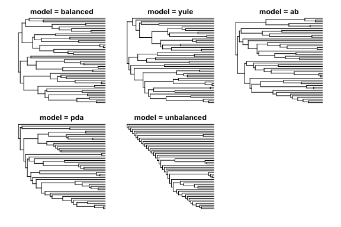

Plot medoid trees for each model.

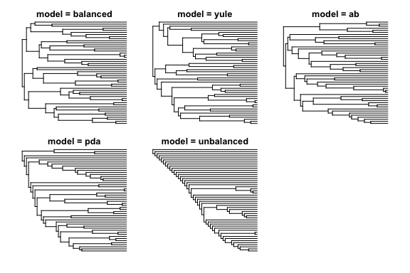

Do MDS

```r
mds <- cmdscale(dmat.L1, eig=T, k=3)
```

Plot 2D MDS of the simulated isochronous trees using unweighted L1 metric.

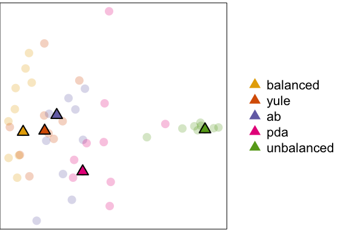

Based on Julia’s Simulation.Rmd

Simulate a genealogy with constant effective population size with 10 tips at time 0 and 40 other tips with uniform sampling times.

Consider two trajectories: uniform and bottleneck.

```r
samp.times = c(0, sort(runif(40, 0, 8)))
n.sampled = c(10, rep(1, 40))

rand.seed <- 346
n.sim <- 20 # number of simulations
n.tip <- length(n.sampled) # number of tips
n.model <- 2
set.seed(rand.seed)
hetero.tr.list <- vector("list", n.model)
hetero.Fmat.list <- vector("list", n.model)

for (i in 1:n.sim) {
    # uniform trajectory
    tmp.sim <- coalsim(samp_times=samp.times, n_sampled=n.sampled,
                       traj=unif_traj)
    tmp.tr <- generate_newick(tmp.sim)
    hetero.tr.list[[1]][[i]] <- tmp.tr$newick
    hetero.Fmat.list[[1]][[i]] <- gen_Fmat(tmp.tr$newick)

    # bottleneck trajectory
    tmp.sim <- coalsim(samp_times=samp.times, n_sampled=n.sampled,
                       traj=bottleneck_traj, method="thin",
                       val_upper=11)
    tmp.tr <- generate_newick(tmp.sim)
    hetero.tr.list[[2]][[i]] <- tmp.tr$newick
    hetero.Fmat.list[[2]][[i]] <- gen_Fmat(tmp.tr$newick)
}

treetypes <- c('uniform', 'bottleneck')
names(hetero.tr.list) <- treetypes
names(hetero.Fmat.list) <- treetypes
```

Compute L2 weighted distance matrix.

```r
hetero.all.Fmat <- unlist(hetero.Fmat.list, recursive=FALSE)
hetero.all.tr <- unlist(hetero.tr.list, recursive=FALSE)
dmat.L2 <- matrix(0, nrow=length(hetero.all.tr), ncol=length(hetero.all.tr))

for (i in 2:length(hetero.all.tr)) {
    print(paste('computing distances from tree', i))
    for (j in 1:(i-1)) {
        dmat.L2[i,j] <- dist_pairwise(hetero.all.tr[[i]],
                                      hetero.all.tr[[j]],
                                      dist.method="l2", weighted=TRUE)
    }
}

tmp <- c(dmat.L2[lower.tri(dmat.L2)])
dmat.L2 <- t(dmat.L2)
dmat.L2[lower.tri(dmat.L2)] <- tmp
```

Find sample Frechet mean tree and medoid tree from the distance matrix.

```r
f.pts <- list()
for (i in 1:n.model) {
    tr.ind <- ((i-1)*n.sim + 1):(i*n.sim)
    f.pts[[i]] <- find.frechet.mean(dmat.L2[tr.ind, tr.ind]) + (i-1)*n.sim
}

m.pts <- list()
for (i in 1:n.model) {
    tr.ind <- ((i-1)*n.sim + 1):(i*n.sim)
    m.pts[[i]] <- find.medoid(dmat.L2[tr.ind, tr.ind]) + (i-1)*n.sim
}
```

Plot sample Frechet mean trees for each model.

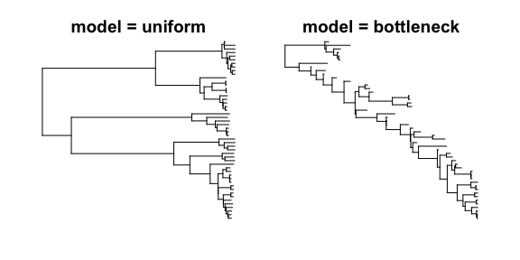

Plot medoid trees for each model.

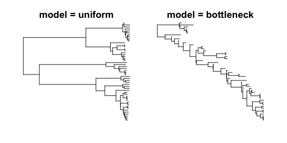

Do MDS

```r
mds <- cmdscale(dmat.L2, eig=T, k=3)
```

Plot 2D MDS of the simulated heterochronous trees using weighted L2 metric.

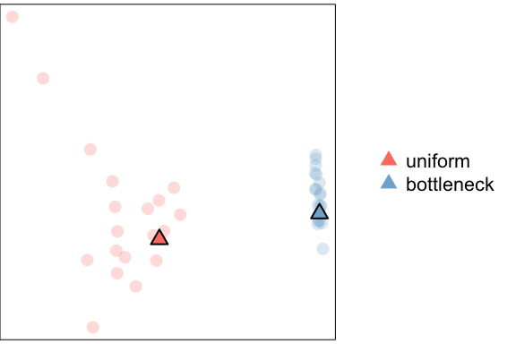